# Analisis para El Gallinero en la comunidad pesquera Maria Elena

*Este documento fue generado por el paquete [`MPAtools`](https://github.com/turfeffect/MPAtools), uno de los entregables del grupo TURFeffect. Los resultados presentados son una version preliminar del software que se esta desarrollando, y no recomendamos la toma de decisiones basado en la informacion aqui presentada*

*Acentos y caracteres especiales omitidos*

# Resumen

**Leyenda**

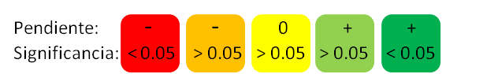

[output not shown]

# Ecologicos

## Peces

### Densidad

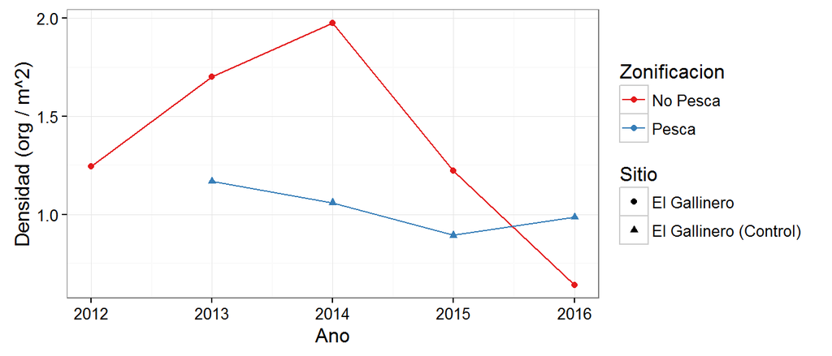

Densidad promedio de peces (org / m^2).

|  | Densidad (org / transecto) |
| --- | --- |
| Ano | -0.07 |
| Zona | 194.98 |
| **Ano:Zona** | -0.10 |
| Constante | 145.40 |
| R<sup>2</sup> | 0.41 |
| Residual Std. Error | 0.39 |
| F Statistic | 1.18 |
| *Note:* | +p < 0.1, ++p<0.05, +++p<0.001 |

### Riqueza

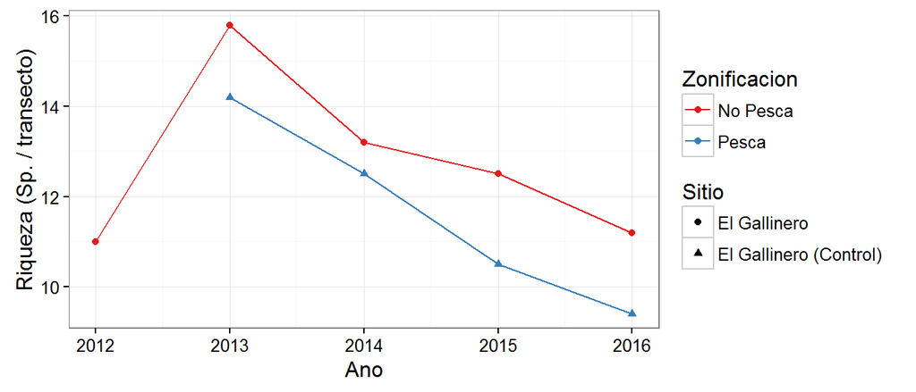

Riqueza promedio de peces (Sp / transecto).

|  | Riqueza (Sp. / transecto) |
| --- | --- |
| Ano | -1.64<sup>+</sup> |
| Zona | -2,718.63 |
| **Ano:Zona** | 1.35 |
| Constante | 3,315.43<sup>+</sup> |
| R<sup>2</sup> | 0.54 |
| Residual Std. Error | 1.69 |
| F Statistic | 1.97 |
| *Note:* | +p < 0.1, ++p<0.05, +++p<0.001 |

### Biomasa

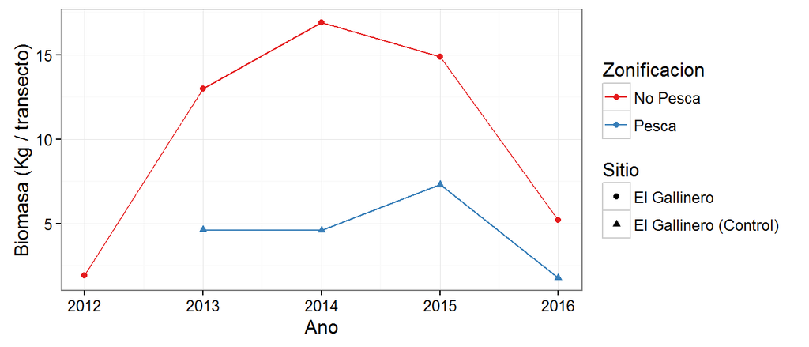

Biomasa promedio de peces (Kg / transecto).

|  | Biomasa (Kg / transecto) |
| --- | --- |
| Ano | -0.59 |
| Zona | -2,893.91 |
| **Ano:Zona** | 1.44 |
| Constante | 1,187.61 |
| R<sup>2</sup> | 0.32 |
| Residual Std. Error | 5.93 |
| F Statistic | 0.80 |
| *Note:* | +p < 0.1, ++p<0.05, +++p<0.001 |

### Nivel trofico

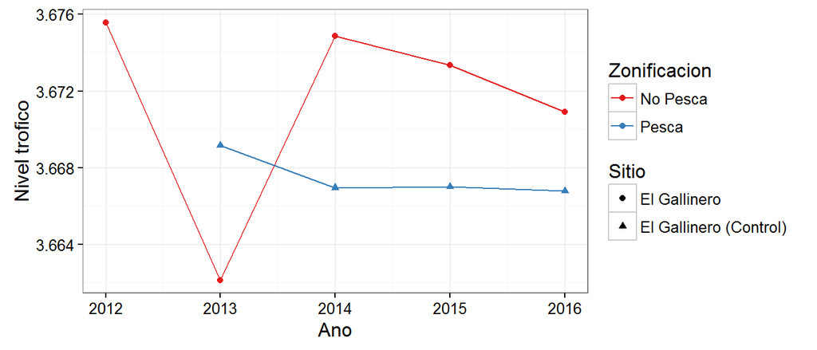

Nivel trofico promedio de peces.

|  | Nivel trofico |
| --- | --- |
| Ano | -0.001 |
| Zona | -1.81 |
| **Ano:Zona** | 0.001 |
| Constante | 5.10 |
| R<sup>2</sup> | 0.23 |
| Residual Std. Error | 0.005 |
| F Statistic | 0.51 |
| *Note:* | +p < 0.1, ++p<0.05, +++p<0.001 |

## Invertebrados

### Densidades

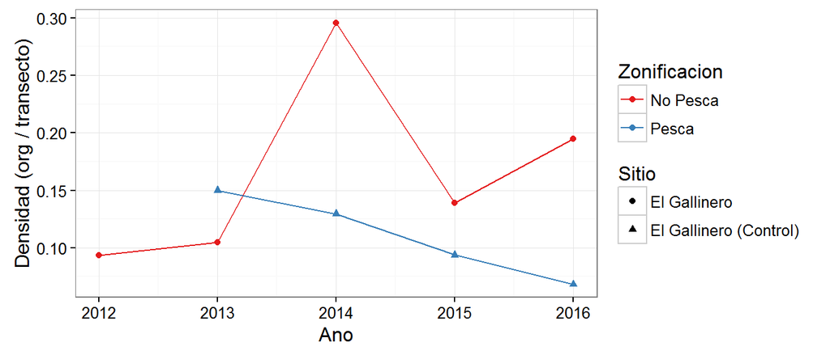

Densidad promedio de invertebrados (org / transecto).

|  | Densidad (org / transecto) |
| --- | --- |
| Ano | -0.03 |
| Zona | -104.30 |
| **Ano:Zona** | 0.05 |
| Constante | 56.69 |
| R<sup>2</sup> | 0.43 |
| Residual Std. Error | 0.07 |
| F Statistic | 1.25 |
| *Note:* | +p < 0.1, ++p<0.05, +++p<0.001 |

## Especies de interes

### Pargos (*Lutjanus sp.*)

#### Densidad

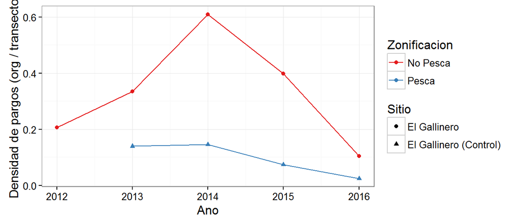

Densidad promedio de pargos (*Lutjanus sp.; org / transecto*)

|  | Densidad (org / transecto) |
| --- | --- |
| Ano | -0.04 |
| Zona | -55.51 |
| **Ano:Zona** | 0.03 |
| Constante | 84.03 |
| R<sup>2</sup> | 0.47 |
| Residual Std. Error | 0.17 |
| F Statistic | 1.49 |
| *Note:* | +p < 0.1, ++p<0.05, +++p<0.001 |

#### Biomasa

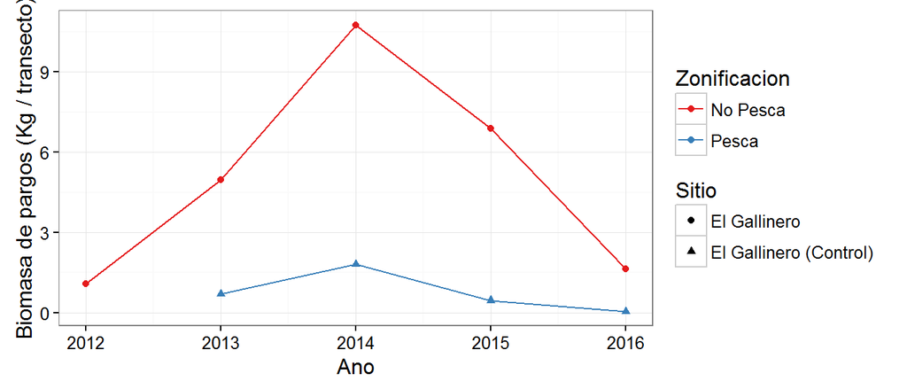

|  | Biomasa (Kg / transecto) |
| --- | --- |
| Ano | -0.33 |
| Zona | -1,273.25 |
| **Ano:Zona** | 0.63 |
| Constante | 665.74 |
| R<sup>2</sup> | 0.40 |
| Residual Std. Error | 3.57 |
| F Statistic | 1.12 |
| *Note:* | +p < 0.1, ++p<0.05, +++p<0.001 |

### Langosta (*Panulirus argus*)

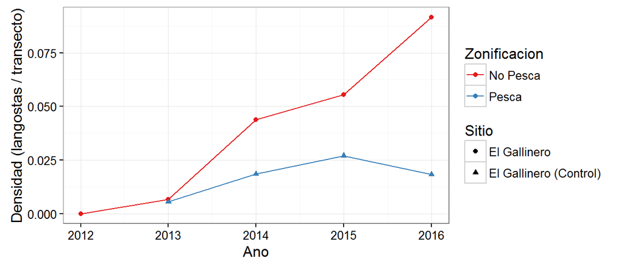

Densidad promedio de langosta (*Panulirus argus*; org / transecto).

|  | Densidad (org / transecto) |
| --- | --- |
| Ano | 0.005 |
| Zona | -37.30<sup>++</sup> |
| **Ano:Zona** | 0.02<sup>++</sup> |
| Constante | -9.43 |
| R<sup>2</sup> | 0.95 |
| Residual Std. Error | 0.01 |
| F Statistic | 29.78<sup>+++</sup> |
| *Note:* | +p < 0.1, ++p<0.05, +++p<0.001 |

### Caracol rosa (*Lobatus gigas*)

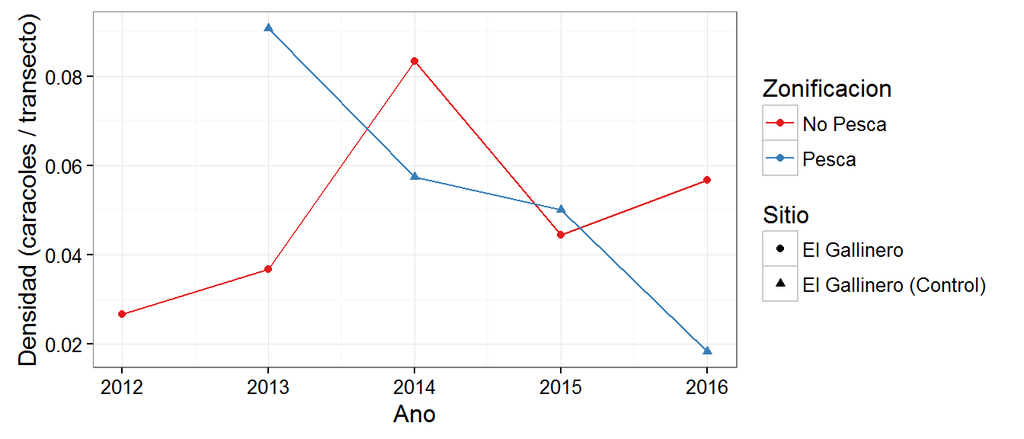

Densidad promedio de caracol rosa (*Lobatus gigas*; org / transecto)

|  | Densidad (org / transecto) |
| --- | --- |
| Ano | -0.02<sup>++</sup> |
| Zona | -58.91<sup>++</sup> |
| **Ano:Zona** | 0.03<sup>++</sup> |
| Constante | 45.31<sup>++</sup> |
| R<sup>2</sup> | 0.66 |
| Residual Std. Error | 0.02 |
| F Statistic | 3.21 |
| *Note:* | +p < 0.1, ++p<0.05, +++p<0.001 |

# Socioeconomico

## Capturas

### Generales

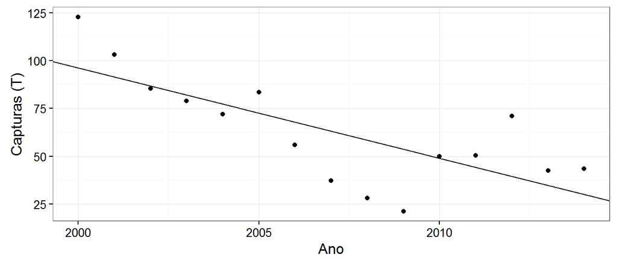

### Especies Objetivo

#### Mero

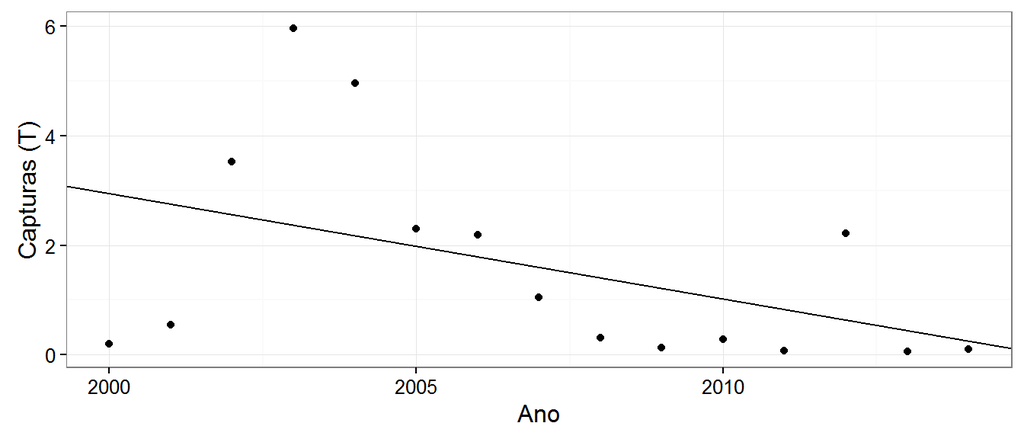

#### Pargo

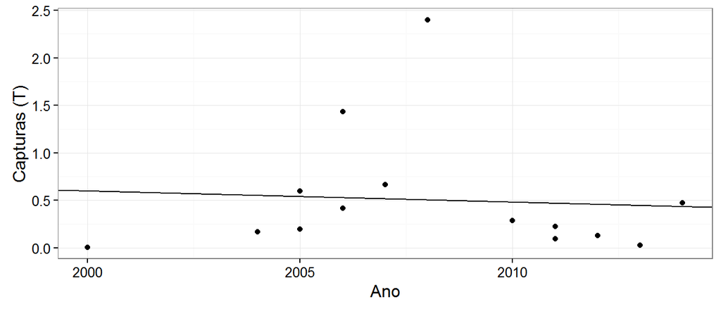

#### Langosta

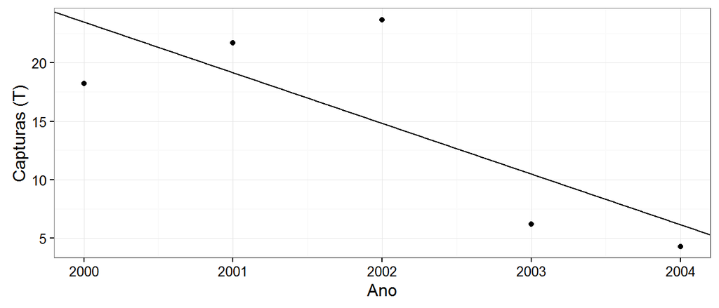

## Ingresos

### Generales

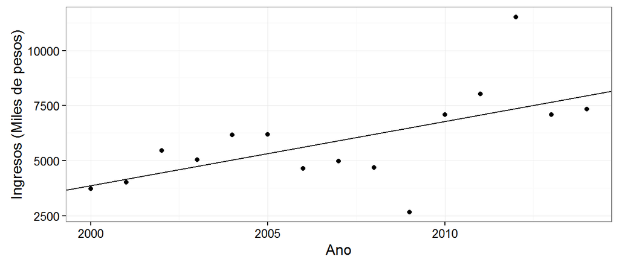

### Especies Objetivo

#### Mero

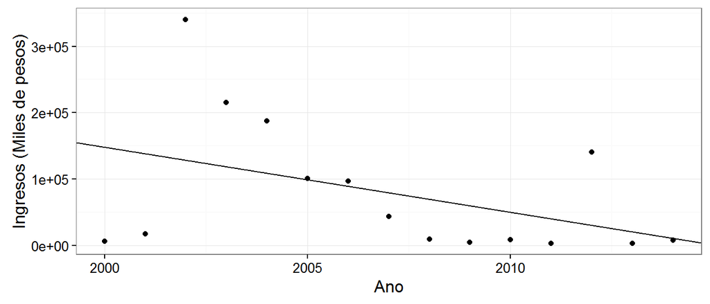

#### Pargo

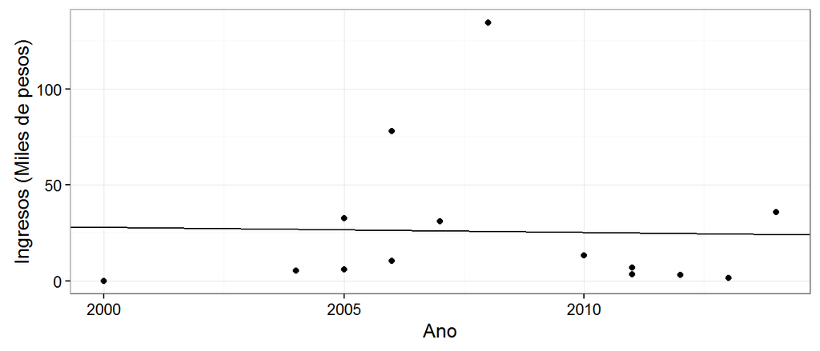

#### Langosta

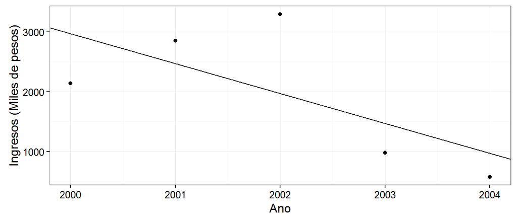

# Gobernanza

*La informacion de gobernanza se presenta con propositos de realizar el ejercicio; de ninguna manera representa una evaluacion que pueda utilizarse para recomendaciones.*

## Acceso a la pesqueria

[1] “Las pesquerías se manejan por medio de permisos (escama) y concesiones (langosta).”

## Numero de pescadores

[1] “48”

## Reconocimiento legal de la reserva

[1] “La reserva recibió reconocimiento legal el 11 de Septiembre del 2012, acordando un periodo de 5 años.”

## Tipo de reserva

[1] “Zona de Refugio Pesquero Total Temporal.”

## Grado de pesca ilegal

[1] “Alto” [1] “Con base en las encuestas realizadas, los pescadores indicaron que existe un alto nivel de pesca ilegal. La comunidad realiza inspecciones de vigilancia cuatro veces al mes.”

## Plan de manejo

[1] “Bajo” [1] “Además del acuerdo publicado en el DOF, existe poca información disponible a los pescadores de la comunidad y otras comunidades. La falta de información sobre el tipo de reserva y ubicación pueden reducir la efectividad de la misma.”

## Procuracion de la reserva

[1] “Desde el establecimiento de las reservas, la comunidad se encarga de realizar cuatro monitoreos mensuales. En las entrevistas, los pescadores mencionaron la necesidad de recibir ayuda del gobierno para incrementar la vigilancia de sus zonas. Si los socios de la cooperativa son sorprendidos dentro de la zona, se convoca una asamblea en la que se decide la penalidad. Sin embargo, cuando los pescadores son de otras comunidades, se explica que son reserva y se pide que abandonen el área.”

## Razonamiento para la ubicacion

[1] “La selección de sitios se basó en el conocimiento de los pescadores, quienes reconocieron el valor de las zonas como hábitat importante para las especies aprovechadas por la cooperativa (meros y pargos). Éstas zonas incluyen parches de arrecife, arenales, áreas de pastos marinos y manglares.”

## Organizacion

[1] “Sociedad Cooperativa de Producción Pesquera”

## Nivel inclusividad

[1] “Alto” [1] “La comunidad fue quien decidió establecer las ZRP. Con ayuda de organizaciones de la sociedad civil, se realizaron talleres en los que los pescadores acordaron la implementación de las ZRP. Los usuarios se involucraron en el diseño, implementación, monitoreo y vigilancia.”

# Referencias

- R Core Team (2015). R: A language and environment for statistical computing. R Foundation for Statistical Computing, Vienna, Austria. URL https://www.R-project.org/.
- JJ Allaire, Joe Cheng, Yihui Xie, Jonathan McPherson, Winston Chang, Jeff Allen, Hadley Wickham, Aron Atkins and Rob Hyndman (2016). rmarkdown: Dynamic Documents for R. R package version 0.9.6. https://CRAN.R-project.org/package=rmarkdown
- Hadley Wickham and Romain Francois (2016). dplyr: A Grammar of Data Manipulation. R package version 0.5.0. https://CRAN.R-project.org/package=dplyr
- Hadley Wickham (2016). tidyr: Easily Tidy Data with `spread()` and `gather()` Functions. R package version 0.6.0. https://CRAN.R-project.org/package=tidyr
- Hlavac, Marek (2015). stargazer: Well-Formatted Regression and Summary Statistics Tables. R package version 5.2. http://CRAN.R-project.org/package=stargazer